# Chapter 2 Inferences in Regression and Correlation Analysis

Bryan Goodrich

2015-08-08

# Chapter 2 – Inferences in Regression and Correlation Analysis

## Load the data sets

```r
data("CH01TA01", package = "ALSM")
data("CH02TA04", package = "ALSM")
```

## Input the Toluca Company Data

```r
.data        <- CH01TA01
names(.data) <- c("x", "y")
fit       <- lm(y ~ x, .data)
```

## TABLE 2.1 and FIGURE 2.2 (p 46)

### Results for Toluca Company Example Obtained in Chapter 1 Regression Output–Toluca Company Example

```r
summary(fit)
```

```
##
## Call:
## lm(formula = y ~ x, data = .data)
##
## Residuals:
##     Min      1Q  Median      3Q     Max
## -83.876 -34.088  -5.982  38.826 103.528
##
## Coefficients:
##             Estimate Std. Error t value       Pr(>|t|)
## (Intercept)   62.366     26.177   2.382         0.0259 *
## x              3.570      0.347  10.290 0.000000000445 ***
## ---
## Signif. codes:  0 '***' 0.001 '**' 0.01 '*' 0.05 '.' 0.1 ' ' 1
##
## Residual standard error: 48.82 on 23 degrees of freedom
## Multiple R-squared:  0.8215, Adjusted R-squared:  0.8138
## F-statistic: 105.9 on 1 and 23 DF,  p-value: 0.0000000004449
```

```r
anova(fit)
```

```
## Analysis of Variance Table
##
## Response: y
##           Df Sum Sq Mean Sq F value          Pr(>F)
## x          1 252378  252378  105.88 0.0000000004449 ***
## Residuals 23  54825    2384
## ---
## Signif. codes:  0 '***' 0.001 '**' 0.01 '*' 0.05 '.' 0.1 ' ' 1
```

```r
tab <- c(
  'n'    = nrow(fit$model),              # 25
  'xbar' = mean(fit$model[[2]]),         # 70
  'b0'   = coef(fit)[[1]],               # 62.366
  'b1'   = coef(fit)[[2]],               # 3.570
  'SSE'  = anova(fit)["Residuals", 2],   # 54,825.460
  'MSE'  = anova(fit)["Residuals", 3],   # 2,383.716
  'SSx'  = sum(scale(.data$x, T, F)^2),  # 19,800
  'SSTO' = sum(anova(fit)[,2]))          # 307,203

round(tab, 2)
```

```
##         n      xbar        b0        b1       SSE       MSE       SSx      SSTO
##     25.00     70.00     62.37      3.57  54825.46   2383.72  19800.00 307203.04
```

## FUNCTION DEFINITION `ci`

#### Description

Predicts values based on a linear model object

#### Usage

```
ci(model, Xh = 0, alpha = 0.1, m = 1,
   interval = c("confidence", "prediction", "band"))
```

#### Arguments

> model – Object of class “lm”. Xh – An optional vector of prediction values. Default results in evaluating the interval about the intercept coefficient. alpha – Significance level for prediction interval. m – Number of new observations on response for a given Xh. interval – Type of interval calculation to use.

#### Notes

This function mimics the predict.lm function in the stats library. The aim is to follow the calculations provided for the examples in Chapter 2. Since the various equations (2.23, 2.25, 2.30, 2.33, 2.36, 2.38a, and 2.39) share the same general form, this function could easily generalize to each of the provided examples. In particular, the estimated standard deviation equation follows the general form in this function where the constant c defaults to 0 under confidence intervals, 1 under predictions. The constant m defaults to 1 unless otherwise specified to be looking for numerous mean responses. Additionally, an interval of “band” is provided. This option uses the Working-Hotelling 1-alpha confidence measure from equations (2.40) and (2.40a). Everything else is the same as a confidence interval.

The following examples will make use of this pedagogical function alongside the use of the R function that provides the same results. It is left to the reader to understand the R function arguments provided.

```r
ci <- function(model, Xh = 0, alpha = 0.1, m = 1, interval = c("confidence", "prediction", "band"))
{
  int   <- match.arg(interval)
  c     <- ifelse(int == "prediction", 1, 0)
  x     <- model$model[[2]]
  n     <- length(x)
  df    <- summary(model)$df[2]
  SSx   <- sum( scale(model$model[[2]], T, F)^2 )
  MSE   <- anova(model)["Residuals", 3]
  dev   <- Xh - mean(x)
  s     <- sqrt( MSE * (c/m + 1/n + dev^2 / SSx) )

  if (int == "band")
  {
    val <- sqrt( 2 * qf(1 - alpha, 2, df) )
  } else
    val <- qt(1 - alpha/2, df)

  pred  <- coef(fit)[[1]] + coef(fit)[[2]] * Xh
  lwr   <- pred - val * s
  upr   <- pred + val * s

  return(cbind(pred, lwr, upr))
}
```

## EXAMPLE (p 49)

#### Confidence Interval for beta0

```r
ci(fit)
```

```
##          pred     lwr      upr
## [1,] 62.36586 17.5011 107.2306
```

```r
confint(fit, parm = 1, level = 0.9)
```

```
##                 5 %     95 %
## (Intercept) 17.5011 107.2306
```

## EXAMPLE (pp 54-5)

#### Confidence Interval for E{Yh}

```r
newdata = c(65, 100)
ci(fit, Xh = newdata)
```

```
##          pred      lwr      upr
## [1,] 294.4290 277.4315 311.4264
## [2,] 419.3861 394.9251 443.8470
```

```r
predict(fit, data.frame(x = newdata), interval = "confidence", level = 0.9)
```

```
##        fit      lwr      upr
## 1 294.4290 277.4315 311.4264
## 2 419.3861 394.9251 443.8470
```

## EXAMPLE (p 59)

#### Prediction Interval for Yh(new) when Parameters Unknown

```r
newdata = 100
ci(fit, Xh = newdata, interval = "prediction")
```

```
##          pred      lwr      upr
## [1,] 419.3861 332.2072 506.5649
```

```r
predict(fit, data.frame(x = newdata), interval = "prediction", level = 0.9)
```

```
##        fit      lwr      upr
## 1 419.3861 332.2072 506.5649
```

## EXAMPLE (p 61)

#### Prediction of Mean of m New Observations Given Xh

```r
ci(fit, newdata, interval = "prediction", m = 3)
```

```
##          pred      lwr      upr
## [1,] 419.3861 365.2356 473.5366
```

```r
predict(fit, data.frame(x = newdata), interval = "prediction",
        level = 0.9, weights = 3)
```

```
##        fit      lwr      upr
## 1 419.3861 365.2356 473.5366
```

## FIGURE 2.6 (p 62)

#### Confidence Bands for Regression Line–Toluca Company Example

Since this user-defined function ci behaves similar to `predict`, it should come as no surprise that this approach to regression bands can be performed using `predict`.

Note that one could replace the below curve statements with something like

> `curve(predict(fit, data.frame(x = x)), add = TRUE)`

```r
ci(fit, 100, interval = "band")  # Example case when Xh = 100
```

```
##          pred      lwr     upr
## [1,] 419.3861 387.1591 451.613
```

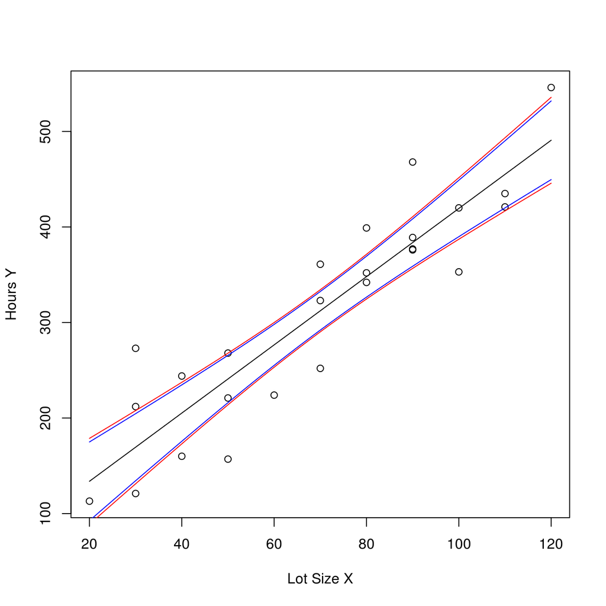

```r
plot(y ~ x, .data, xlab = "Lot Size X", ylab = "Hours Y")

curve(ci(fit, x, interval = "band")[, "pred"], add = TRUE)
curve(ci(fit, x, interval = "band")[,  "lwr"], add = TRUE, col = "red")
curve(ci(fit, x, interval = "band")[,  "upr"], add = TRUE, col = "red")
curve(predict(fit, data.frame(x = x), int = "c")[, 2], add = TRUE, col = "blue")
curve(predict(fit, data.frame(x = x), int = "c")[, 3], add = TRUE, col = "blue")
```

## EXAMPLE (p 71)

#### F-test of beta1

```r
MSR   <- anova(fit)["x",         "Mean Sq"]   # 252,377.600
MSE   <- anova(fit)["Residuals", "Mean Sq"]   #   2,383.716
Fstat <- MSR / MSE                            #     105.876
fval  <- qf(0.95, 1, 23)                      #       4.279
round(c('MSR' = MSR, 'MSE' = MSE, 'F' = Fstat, 'fval' = fval), 4)
```

```
##         MSR         MSE           F        fval
## 252377.5808   2383.7156    105.8757      4.2793
```

```r
if (abs(Fstat) <= fval) {
  print("Conclude H0")                        # Fail to reject H0
} else
  print("Conclude Ha")                        # Reject H0
```

```
## [1] "Conclude Ha"
```

## EXAMPLE (pp 75-6)

#### Coefficient of Determination and Coefficient of Correlation

```r
tab <- c(
  'SSR'  = anova(fit)["x", "Mean Sq"],         # 252,377
  'SSTO' = sum( anova(fit)["Sum Sq"] ),        # 307,203
  'R2'   = summary(fit)$r.squared,             # 0.8215 (= SSR / SSTO)
  'r'    = with(.data, cor(x, y)))                # 0.9064 (= sqrt(R2) )

round(tab, 4)
```

```
##         SSR        SSTO          R2           r
## 252377.5808 307203.0400      0.8215      0.9064
```

## Input the Sales Marketing Data

```r
.data <- CH02TA04
y1 <- .data[, 1]
y2 <- .data[, 2]
```

## TABLE 2.4 (pp 87-9)

#### Data on Population, Expenditures and Their Ranks–Sales Marketing Example

```r
cbind(
  'Population'  = y1,
  'Expenditure' = y2,
  'R1'          = rank(y1),
  'R2'          = rank(y2))
```

```
##       Population Expenditure R1 R2
##  [1,]         29         127  1  2
##  [2,]        435         214  8 11
##  [3,]         86         133  3  4
##  [4,]       1090         208 11 10
##  [5,]        219         153  7  6
##  [6,]        503         184  9  8
##  [7,]         47         130  2  3
##  [8,]       3524         217 12 12
##  [9,]        185         141  6  5
## [10,]         98         154  5  7
## [11,]        952         194 10  9
## [12,]         89         103  4  1
```

```r
# Calculate Spearman Correlation Information
c('rho' =  sum(scale(rank(y1), T, F) * scale(rank(y2), T, F)) /
           sqrt(sum(scale(rank(y1), T, F)^2) * sum(scale(rank(y2), T, F)^2)))
```

```
##       rho
## 0.8951049
```

```r
cor.test(y1, y2, method = "spearman")$estimate    # Spearman Rho = 0.895
```

```
##       rho
## 0.8951049
```

```r
c('rho' = cor(rank(y1), rank(y2)))                # Alternative R method
```

```
##       rho
## 0.8951049
```

```r
# t* calculation
c('tstar' = (cor(rank(y1), rank(y2)) * sqrt(length(y1) - 2)) /
             sqrt(1 - cor(rank(y1), rank(y2))^2))
```

```
##    tstar
## 6.348625
```